# 7_findings.R

dhicks1

Sat Jun 3 11:03:20 2017

The document briefly reports some findings from the cluster analysis conducted in `5_clustering.R`.

# Summary

Advocacy documents, taken together and compared to industry documents taken together, make greater use of personal and emotionally-loaded language rather than technical toxicological language, refer to diseases rather than toxicological studies, and connect the use of glyphosate to other prominent public scientific controversies (genetically modified foods and, to a lesser extent, vaccines).

Industry documents make greater use of technical language, including discussions of both particular studies and general research quality standards. Industry connects the use of glyphosate to the agronomic benefits of genetically modified crops, especially sugarbeets.

The text of public comments, by themselves, cannot tell us how they influenced EPA’s decisionmaking. However, both STS researchers and political philosophers have noted that personal narratives and emotionally-loaded language are often discounted — as anecdotal, uninformed, and irrational — in favor of the more technical, emotionally moderated language of credentialed experts. It is at least plausible that the use of personal and emotionally-loaded language worked against advocacy in this case.

The remainder of this document briefly examines the content of each of the advocacy- and industry-associated clusters. At the end, I consider work by Guthman and Brown on a preference for consumer-based criticisms of pesticides, rather than worker-based criticisms.

```r
library(tidyverse)
library(stringr)
library(wordVectors)

load('5_clustering.Rdata')
names(cluster_terms) = str_c('cluster_', 1:length(cluster_terms))
```

First we re-plot the dotplots of vector projections (excluding cluster 16, which contains only a single comment). Note the use of a log scale.

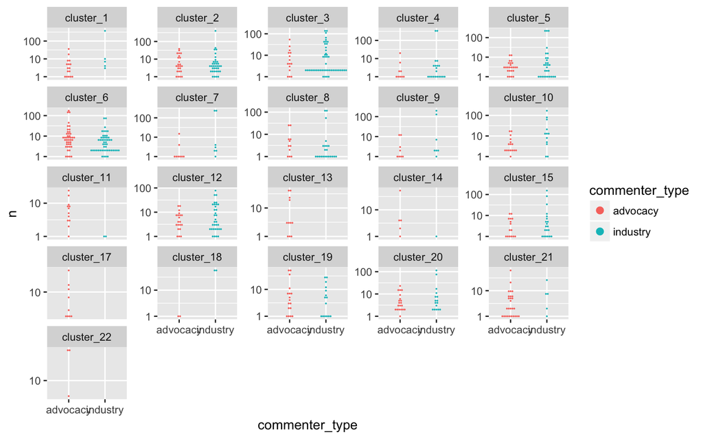

```r
comment_counts %>%
    filter(cluster != 'cluster_16') %>%
    ggplot(aes(commenter_type, n,
               fill = commenter_type)) +
    geom_dotplot(binaxis = 'y', stackdir = 'center',
                 color = NA, dotsize = 1.2) +
    facet_wrap(~ cluster, scales = 'free_y') +
    scale_y_log10()
```

Inspecting these dotplots, we identify clusters that appear to be especially associated with advocacy or industry.

```r
advocacy_clusters = c(6, 11, 13, 14, 17, 19, 21, 22)

industry_clusters = c(1:5, 7:10, 12, 15, 18, 20)
```

Given these cluster associations, we next re-plot the MDS projection. This plot projects the full 100-dimensional vectors down into 2-dimensional space. The plot indicates shows that advocacy and industry clusters are generally not close to each other, meaning that (with respect to the terms used in this clustering exercise), industry and advocacy generally use different language and talk about different concepts. Recall that the terms were selected using information gain to distinguish the two types of comments. There are two pairs of clusters that are the exceptions to this trend — industry and advocacy clusters that are close to each other: 12 and 22, and 7 and 19.

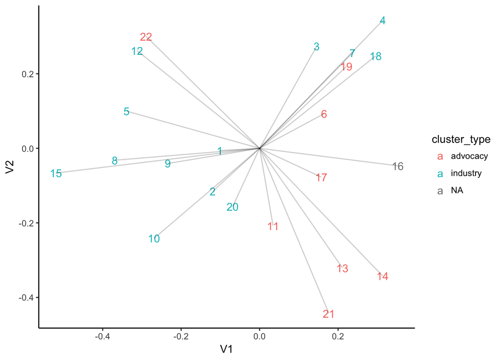

```r
## MDS projection of cluster vectors
cluster_vectors %>%
    map(normalize_lengths) %>%
    # map(as.matrix) %>%
    reduce(rbind) %>%
    {.%*%t(.)} %>%
    {1-.} %>%
    cmdscale() %>%
    as_tibble() %>%
    mutate(cluster = 1:nrow(.),
           cluster_type = ifelse(cluster %in% industry_clusters, 'industry',
                              ifelse(cluster %in% advocacy_clusters, 'advocacy',
                                   NA))) %>%
    ggplot() +
    geom_text(aes(V1, V2, label = cluster, color = cluster_type)) +
    geom_segment(aes(0, 0, xend = V1, yend = V2), alpha = .2) +
    theme_classic()
```

## Advocacy clusters

### 6

```r
cluster_terms[[6]]
```

```
##  [1] "we"                 "our"                "ourselves"
##  [4] "courage"            "hope"               "listening"
##  [7] "if_you"             "think"              "someone"
## [10] "vote"               "paying"             "you"
## [13] "your"               "now"                "our_food"
## [16] "feed_crops"         "stop"               "do_your_job"
## [19] "please_stop"        "poisoning_our"      "stuff"
## [22] "hurting"            "toxic_chemicals"    "stop_poisoning"
## [25] "our_children"       "future_generations"
```

This cluster includes both personal and emotionally-charged language. Examples of personal language includes the use of first- and second-person pronouns; examples of emotionally-charged language include a few positive (“courage,” “hope”) and negative terms (“stop,” “do your job,” “please stop,” “poisoning our,” “hurting,” “toxic chemicals”), as well as references to children and future generations.

### 11

```r
cluster_terms[[11]]
```

```
##  [1] "pathways"                "modern_diseases_iv"
##  [3] "modern_diseases"         "amino_acid_biosynthesis"
##  [5] "gut_microbiome_pathways" "cytochrome_p450_enzymes"
##  [7] "suppression"             "seneff"
##  [9] "samsel"                  "stephanie_seneff"
## [11] "mit"
```

This cluster appears to refer to the work of Stephanie Seneff, a MIT computer scientist https://en.wikipedia.org/wiki/Stephanie_Seneff#Research_on_biology_and_medical_topics; https://people.csail.mit.edu/seneff/. Seneff has published highly controversial work hypothesizing that glyphosate can interfere with the human microbiome in ways that, she suggests, might cause autism and Alzheimer’s disease.

### 13

```r
cluster_terms[[13]]
```

```
##  [1] "autism"         "gut_microbiome" "immune_system"  "destroys"
##  [5] "biome"          "biomes"         "gut"            "leaky"
##  [9] "gut_bacteria"   "micro"
```

This cluster also appears to refer to the work of Stephanie Seneff. This cluster’s language is more specific than cluster 11’s, and perhaps for this reason it does not have the false positive industry comments.

### 14

```r
cluster_terms[[14]]
```

```
## [1] "hypertension" "bowel"        "throat"       "infertility"
## [5] "auto_immune"  "disorder"     "obesity"      "diabetes"
```

This cluster makes further references to health concerns associated with glyphosate. Z-scores for clusters 13 and 14 are strongly correlated.

```r
comment_z %>%
    select(comment_id, cluster, magnitude) %>%
    filter(cluster %in% c('cluster_13', 'cluster_14')) %>%
    spread(cluster, magnitude) %>%
    select(-comment_id) %>%
    cor()
```

```
##            cluster_13 cluster_14
## cluster_13  1.0000000  0.8444278
## cluster_14  0.8444278  1.0000000
```

### 17

```r
cluster_terms[[17]]
```

```
## [1] "mmr_ii"         "dtap"           "sanofi_pasteur" "adacel"
## [5] "vaccine"        "flu"            "mmr"
```

This cluster refers to vaccines. Specifically, the anti-GMO advocacy organization Moms Across America http://www.momsacrossamerica.com/ has several comments in the docket reporting findings of glyphosate contamination in vaccines.

### 19

```r
cluster_terms[[19]]
```

```
## [1] "glufosinate" "01p"         "crops"       "corn"        "soy"
## [6] "corn_soy"
```

```r
comment_counts %>%
    filter(cluster == 'cluster_19',
           n > 15) %>%
    arrange(desc(n))
```

```
## # A tibble: 6 × 6
##                  comment_id    cluster     n commenter_type valence
##                       <chr>     <fctr> <int>          <chr>   <chr>
## 1 EPA-HQ-OPP-2016-0385-0473 cluster_19    54       advocacy     neg
## 2 EPA-HQ-OPP-2016-0385-0507 cluster_19    48       advocacy     neg
## 3 EPA-HQ-OPP-2016-0385-0419 cluster_19    36       advocacy     neg
## 4 EPA-HQ-OPP-2016-0385-0485 cluster_19    28       industry     pos
## 5 EPA-HQ-OPP-2016-0385-0502 cluster_19    28       industry     pos
## 6 EPA-HQ-OPP-2016-0385-0511 cluster_19    19       industry     pos
## # ... with 1 more variables: comment_text <chr>
```

This cluster appears to refer to the use of glyphosate on genetically modified corn, soy, and (on the industry side) sugarbeet. On the MDS plot, this cluster is close to cluster 7, which is an industry cluster discussing the use of glyphosate in the sugarbeet industry. It is also close to cluster 18, which is another industry cluster discussing sugarbeets.

### 21

```r
cluster_terms[[21]]
```

```
## [1] "breast"     "prostate"   "cancers"    "pancreatic" "thyroid"
## [6] "ovary"
```

This cluster appears to refer to several specific kinds of cancer.

### 22

```r
cluster_terms[[22]]
```

```
## [1] "mot"        "vacatur"    "vacate"     "remand"     "enlist_duo"
## [6] "dow's"
```

```r
comment_counts %>%
    filter(cluster == 'cluster_22')
```

```
## # A tibble: 3 × 6
##                  comment_id    cluster     n commenter_type valence
##                       <chr>     <fctr> <int>          <chr>   <chr>
## 1 EPA-HQ-OPP-2016-0385-0446 cluster_22    27       advocacy     neg
## 2 EPA-HQ-OPP-2016-0385-0501 cluster_22    27       advocacy     neg
## 3 EPA-HQ-OPP-2016-0385-0507 cluster_22     6       advocacy     neg
## # ... with 1 more variables: comment_text <chr>
```

On the MDS plot, this cluster is close to cluster 12. That cluster is difficult to interpret; it appears to refer to members of an industry-sponsored expert panel, and perhaps members of the FIFRA SAP as well. It may be that those names occurred somewhat near substantive discussions of the legal exchange over Enlist Duo. However, this would require manual inspection of these comments.

## Industry Clusters

### 1

```r
cluster_terms[[1]]
```

```
##  [1] "810"
##  [2] "p_poly3"
##  [3] "0.02"
##  [4] "cd_1"
##  [5] "cd_1_combined"
##  [6] "0.008"
##  [7] "0.062"
##  [8] "0.063"
##  [9] "p_value"
## [10] "p_0.059"
## [11] "kidney_tumor_incidence"
## [12] "decreasing"
## [13] "trend"
## [14] "1993_atkinson_study"
## [15] "0.042"
```

[output cut: 23 more lines]

This cluster includes technical language reporting the results of toxicological safety studies. “Portier” refers to Christopher Portier, the lead toxicologist on the IARC review of glyphosate. The IARC review — and a related paper, comparing IARC’s methods to those of other government agencies — are cited throughout the docket. Portier was initially appointed to the SAP for EPA’s review of glyphosate. In comment 0005, CropLife America complained that “Dr. Portier has regularly engaged in policy advocacy against glyphosate” and therefore has “disqualifying biases for the purposes of appointment to the FIFRA SAP October panel.” Portier responded to these objections in comment 0371, and his work is a significant subject of contention throughout the docket.

```r
tokens_df %>%
    filter(token == 'portier') %>%
    group_by(comment_id, commenter_type, valence) %>%
    summarize(n = n()) %>%
    filter(n > 1)
```

```
## Source: local data frame [10 x 4]
## Groups: comment_id, commenter_type [10]
##
##                   comment_id commenter_type valence     n
##                        <chr>          <chr>   <chr> <int>
## 1  EPA-HQ-OPP-2016-0385-0005       industry     pos    11
## 2  EPA-HQ-OPP-2016-0385-0416       industry     pos     8
## 3  EPA-HQ-OPP-2016-0385-0446       advocacy     neg     9
## 4  EPA-HQ-OPP-2016-0385-0482       industry     pos     2
## 5  EPA-HQ-OPP-2016-0385-0491       industry     pos     2
## 6  EPA-HQ-OPP-2016-0385-0501       advocacy     neg    11
## 7  EPA-HQ-OPP-2016-0385-0504       advocacy     neg     6
## 8  EPA-HQ-OPP-2016-0385-0509       industry     pos     2
## 9  EPA-HQ-OPP-2016-0385-0510       advocacy     neg     8
## 10 EPA-HQ-OPP-2016-0385-0525       industry     pos    52
```

### 2

```r
cluster_terms[[2]]
```

```
##  [1] "no"                      "excessively"
##  [3] "yes"                     "adequately_high"
##  [5] "yes_no"                  "no_na"
##  [7] "wistar_rats"             "albino_rats"
##  [9] "sprague_dawley_rats"     "thyroid_c_cell_adenomas"
## [11] "ss"                      "target_organ"
## [13] "unusually_low"           "2009b"
## [15] "reyna"                   "gordon_1973"
## [17] "suresh_1996"             "pavkov"
## [19] "wyand"                   "atkinson_et_al"
## [21] "1993a"                   "wood_et_al"
## [23] "sugimoto_1997"           "cd_1_mice"
## [25] "spraguedawley_rats"      "no_yes_yes"
## [27] "yes_yes"                 "lankas_1981"
## [29] "brammer_2001"            "atkinson"
## [31] "1993b"                   "swiss"
## [33] "knezevich"               "hogan_1983"
```

### 3

```r
cluster_terms[[3]]
```

```
##  [1] "practices"                      "plant"
##  [3] "compete"                        "precious"
##  [5] "greenhouse"                     "less_fuel"
##  [7] "soil_erosion"                   "carbon"
##  [9] "farms"                          "neighbors"
## [11] "farmers"                        "soybean_farmers"
## [13] "reduced"                        "cropping_systems"
## [15] "adoption"                       "conservation_tillage"
## [17] "tolerant"                       "corn_cotton"
## [19] "mechanical"                     "manage"
## [21] "emissions"                      "fuel"
## [23] "tillage"                        "till"
## [25] "cultivation"                    "cover_crops"
## [27] "wind_erosion"                   "no_till"
## [29] "conservation_tillage_practices" "weed_control"
## [31] "labor"                          "crop"
## [33] "weeds"
```

This cluster focuses on the agricultural uses of glyphosate, especially its ecological-environmental benefits when paired with genetically modified crops. One of the primary arguments for this use of glyphosate is that it reduces the need to till the soil for weed control, reducing erosion and promoting carbon capture.

### 4

```r
cluster_terms[[4]]
```

```
##  [1] "growers"               "commercialization"
##  [3] "technology"            "stewardship_agreement"
##  [5] "grower"                "rrsb"
##  [7] "conventional_seed"     "mixing"
##  [9] "roundup_ready"         "female_plant"
## [11] "sugarbeet"             "resistant_sugarbeets"
## [13] "varieties"             "approximately_160"
## [15] "successfully"          "distance"
## [17] "isolation_distances"   "sugarbeet_seed"
## [19] "cross_pollination"     "seed"
## [21] "willamette_valley"     "crop_production"
## [23] "red_beet_seed"         "swiss_chard"
## [25] "red_beet"              "pollen"
## [27] "pollinate"             "seed_stalk"
## [29] "other_beta_crops"      "compatible"
## [31] "proximity"             "red_table"
## [33] "sugarbeet_pollen"
```

This cluster discusses the agricultural benefits of glyphosate, especially on genetically modified sugarbeets. It includes references to agricultural practices to reduce the unintentional spread of GM seeds.

### 5

```r
cluster_terms[[5]]
```

```
##  [1] "peer_review"
##  [2] "quality_standards"
##  [3] "second_highly_influential"
##  [4] "subset"
##  [5] "meets"
##  [6] "influential_scientific_information"
##  [7] "cancer_assessment"
##  [8] "hisa"
##  [9] "federal_government_quality_standards"
## [10] "sap's_review"
## [11] "must_meet"
## [12] "information"
## [13] "higher_degree"
## [14] "influential_information"
## [15] "reproducibility"
```

[output cut: 16 more lines]

This cluster focuses on the research quality standards used by regulators to determine whether or not a given study should be included in the systematic review.

### 7

```r
cluster_terms[[7]]
```

```
##  [1] "separated"                "roundup_ready_sugarbeets"
##  [3] "molecular_level"          "molasses"
##  [5] "extracted_from"           "sugar_extracted_from"
##  [7] "organic_sugar_cane"       "pulp"
##  [9] "cattle"                   "sugar"
## [11] "sucrose"                  "conventional"
## [13] "tolerant_sugarbeets"      "provider"
## [15] "sugarbeets"               "h7_1_roundup_ready"
```

This cluster appears to discuss the use of glyphosate by the sugarbeet industry. Most commercial sugarbeets are genetically modified to tolerate glyphosate.

### 8

```r
cluster_terms[[8]]
```

```
##  [1] "genotoxicity"       "brusick_et_al"      "expert_panel"
##  [4] "based_formulations" "kirkland"           "dj"
##  [7] "references"         "acquavella"         "david_kirkland"
## [10] "larry_kier"         "williams"           "aardema"
## [13] "brusick"
```

The names in this cluster are the members of an industry-sponsored expert review panel.

### 9

```r
cluster_terms[[9]]
```

```
##  [1] "acquavella_et_al"           "exposure_misclassification"
##  [3] "biomonitoring"              "acquavella_jf"
##  [5] "insights"                   "cohort"
##  [7] "ahs_cohort"                 "nhl_case_control"
##  [9] "casecontrol_studies"        "de_roos_et_al"
## [11] "ahs"                        "case_control_studies"
```

```r
comment_counts %>%
    filter(cluster == 'cluster_9',
           n > 10)
```

```
## # A tibble: 4 × 6
##                  comment_id   cluster     n commenter_type valence
##                       <chr>    <fctr> <int>          <chr>   <chr>
## 1 EPA-HQ-OPP-2016-0385-0399 cluster_9   128       industry     pos
## 2 EPA-HQ-OPP-2016-0385-0446 cluster_9    12       advocacy     neg
## 3 EPA-HQ-OPP-2016-0385-0501 cluster_9    12       advocacy     neg
## 4 EPA-HQ-OPP-2016-0385-0525 cluster_9   197       industry     pos
## # ... with 1 more variables: comment_text <chr>
```

Acquavella et al refers to the industry-sponsored expert review panel; “biomonitoring,” “cohort” and “case control” refer to different types of toxicological study. The two industry comments contain large attachments with detailed toxicological reviews. The two advocacy comments both contain copies of a 15-page document prepared by the Natural Resources Defense Council, which also includes a review of the toxicological literature on glyphosate.

### 10

```r
cluster_terms[[10]]
```

```
##  [1] "non_mammalian"   "mammalian"       "genotoxic"
##  [4] "comet"           "gene_mutation"   "mammalian_cells"
##  [7] "dna_damage"      "vitro"           "vivo"
## [10] "micronucleus"    "clastogen"
```

The terms in this cluster appear to focus on testing for DNA damage due to glyphosate.

### 12

```r
cluster_terms[[12]]
```

```
##  [1] "sap"              "fifra_sap"        "convene"
##  [4] "nominations"      "candidates"       "ad_hoc_members"
##  [7] "cla"              "john_acquavella"  "croplife_america"
## [10] "janet_e_collins"  "r.d"
```

This cluster is difficult to interpret; it appears to refer to a few members of the industry-sponsored expert panel, as well as the FIFRA SAP itself.

### 15

```r
cluster_terms[[15]]
```

```
## [1] "inform"                            "evaluation_process"
## [3] "charge_question"                   "laboratory_animal_carcinogenicity"
## [5] "please_comment_on"                 "weight"
## [7] "integration"
```

This cluster may originate with charge questions posed to the FIFRA SAP, asking them to comment on the process of evaluating studies for inclusion in the systematic review.

### 18

```r
cluster_terms[[18]]
```

```
## [1] "beet"       "subsp"      "sea"        "import"     "beet_sugar"
## [6] "southern"
```

This is another sugarbeet cluster.

### 20

```r
cluster_terms[[20]]
```

```
## [1] "environ_toxicol" "et_al"           "biol"            "romano"
## [5] "arch"            "chemosphere"
```

This cluster is difficult to interpret. Several of its terms appear to be abbreviations, and perhaps were extracted from citations.

## Workers and consumers

Guthman and Brown examined public comments on methyl iodide registration in California, observing that references to consumer health are about twice as comment as references to worker health. They argue that “consumer-citizenship” “loses sight of those most subject to harm [namely, workers and their children]; at worst, following Foucault, the exaltation of certain bodies is a disregard of others, effectively allowing them to die.”

To examine this phenomenon in the glyphosate docket, we first examine the relationship between the magnitude of a word2vec vector (the length of the vector, in the abstract space of word embeddings) and the occurrence of the corresponding term in the dataset.

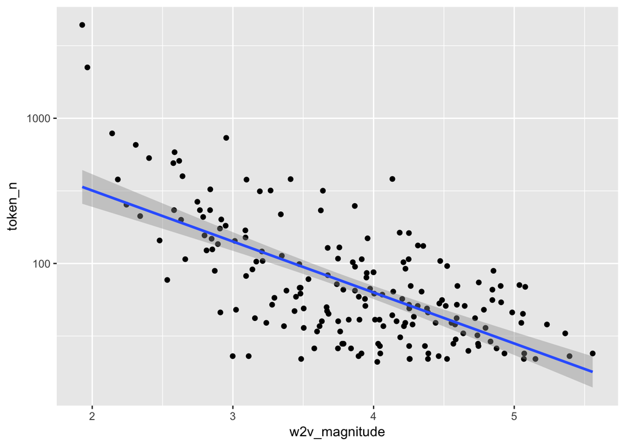

```r
magnitudes(focal_model) %>%
    tibble(token = names(.),
           w2v_magnitude = .) %>%
    inner_join(token_counts_df) %>%
    group_by(token, w2v_magnitude) %>%
    summarize(token_n = sum(token_n)) %>%
    ggplot(aes(w2v_magnitude, token_n)) +
    geom_point() +
    # geom_smooth() +
    geom_smooth(method = 'lm') +
    scale_y_log10()
```

There is a negative exponential relationship between vector magnitude and token count: the longer the vector, the less frequent the term.

```r
magnitudes(focal_model) %>%
    sort() %>%
    .[1:25]
```

```
##          in         for          it         its         but         was
##    1.928977    1.965654    2.141677    2.182062    2.243408    2.309486
##        they        data       being         now           i       found
##    2.340863    2.404014    2.479079    2.533354    2.576723    2.581702
##          no      review    chemical   potential      people    monsanto
##    2.585486    2.618271    2.631706    2.641866    2.661385    2.747496
##    industry          my         had   chemicals information        food
##    2.765401    2.788645    2.798326    2.812764    2.837751    2.839186
##       toxic
##    2.848785
```

```r
magnitudes(focal_model) %>%
    sort(decreasing = TRUE) %>%
    .[1:25]
```

```
## omb_peer_review_bulletin                  yes_yes                     hisa
##                 5.557514                 5.392901                 5.362411
##                 bulletin          reproducibility                      iqa
##                 5.232487                 5.150710                 5.078183
##                      cre              swiss_chard                      omb
##                 5.070919                 5.068428                 5.061680
##                   pose_a                     beet              tumor_rates
##                 5.050342                 5.036797                 4.985366
##                  brusick        quality_standards                     nrdc
##                 4.930389                 4.906780                 4.903429
##               beet_sugar             case_control                      yes
##                 4.874254                 4.852228                 4.844707
##          charge_question                   grower                varieties
##                 4.844423                 4.831354                 4.795835
##             iprovalicarb              peer_review                      moa
##                 4.784156                 4.747768                 4.745695
##               enlist_duo
##                 4.742630
```

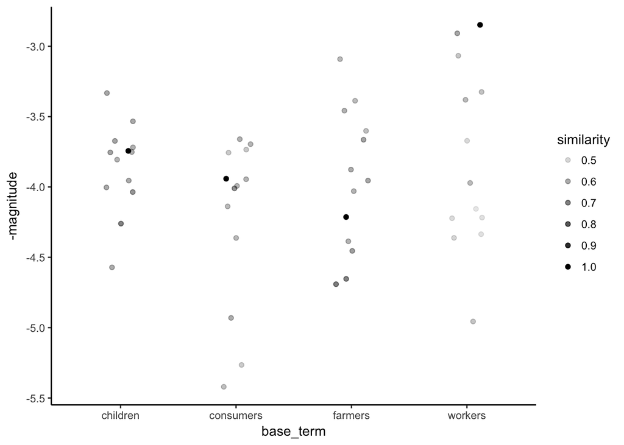

```r
term_magnitudes = c('workers', 'consumers', 'children', 'farmers') %>%
    `names<-`(., .) %>%
    map(~ closest_to(model, .x, fancy_names = FALSE, n = 13)) %>%
    bind_rows(.id = 'base_term') %>%
    mutate(magnitude = {model[[word, average = FALSE]] %>%
                            magnitudes()}) %>%
    arrange(magnitude)

ggplot(term_magnitudes,
       aes(base_term, -magnitude, alpha = similarity)) +
    geom_point(position = position_jitter(width = .15)) +
    theme_classic()
```

The plot suggests that “workers” and its related terms are generally more common than “consumers” and its related terms. The next chunk calculates the mean magnitude, and its standard error, weighting each term by its similarity to the base term. “Consumers” has the largest weighted magnitude (i.e., the lowest prevalence in the dataset), due to a few terms with especially high magnitude; “workers” has the smallest (i.e., the highest prevalence in the dataset), both on its own and due to relatively low similarity and its high-magnitude terms.

```r
term_magnitudes %>%
    group_by(base_term) %>%
    summarize(mean_mag = Hmisc::wtd.mean(magnitude,
                                         weights = similarity,
                                         normwt = TRUE),
              mean_se = sqrt(Hmisc::wtd.var(magnitude,
                                     weights = similarity,
                                     normwt = TRUE) / n()))
```

```
## # A tibble: 4 × 3
##   base_term mean_mag    mean_se
##       <chr>    <dbl>      <dbl>
## 1  children 3.856607 0.08653895
## 2 consumers 4.198415 0.16139408
## 3   farmers 3.996845 0.13893820
## 4   workers 3.714364 0.18982848
```

Further, we can use a t-test against the null hypothesis of no difference for each pair of terms. In the table below, the p value has been corrected for multiple comparisons using a version of the Bonferonni correction.

```r
term_magnitudes %>%
    group_by(base_term) %>%
    summarize(mean_mag = Hmisc::wtd.mean(magnitude,
                                         weights = similarity,
                                         normwt = TRUE),
              mean_se = sqrt(Hmisc::wtd.var(magnitude,
                                          weights = similarity,
                                          normwt = TRUE) / n()),
              n = n()) %>%
    merge(., ., by = NULL) %>%
    filter(base_term.x < base_term.y) %>%
    arrange(base_term.x) %>%
    mutate(abs_diff_mean = abs(mean_mag.x - mean_mag.y),
           diff_se = sqrt(mean_se.x^2/n.x + mean_se.y^2/n.y),
           t = abs_diff_mean / (diff_se),
           df = (n.x-1) * (mean_se.x^2 + mean_se.y^2)^2 / (mean_se.x^4 + mean_se.y^4),
           p_uncorr = pt(t, df, lower.tail = FALSE),
           ## Correct for multiple comparisons by multiplying by the
           ## number of comparisons made
           p = p_uncorr * n()) %>%
    select(base_term.x, base_term.y, abs_diff_mean, diff_se, t, df, p)
```

```
##   base_term.x base_term.y abs_diff_mean    diff_se        t       df
## 1    children   consumers     0.3418074 0.05079146 6.729623 18.37334
## 2    children     farmers     0.1402376 0.04539808 3.089066 20.09285
## 3    children     workers     0.1422439 0.05786180 2.458339 16.78132
## 4   consumers     farmers     0.2015697 0.05906442 3.412710 23.48074
## 5   consumers     workers     0.4840513 0.06910577 7.004499 23.39462
## 6     farmers     workers     0.2824816 0.06524432 4.329596 21.98993
##              p
## 1 7.059826e-06
## 2 1.729347e-02
## 3 7.542600e-02
## 4 7.005152e-03
## 5 1.056069e-06
## 6 8.098770e-04
```

Using the conventional threshold of $p < .05 = 5 \times 10^{-2}$ for statistical significance, all of these differences are statistically significant except for children-workers. In particular, consumers-workers has the largest absolute difference in weighted means.

These results do not indicate the same phenomenon identified by Guthman and Brown. However, the text mining approach taken here is not sensitive to context; in particular, it cannot distinguish the way different groups of commenters (industry vs. advocacy organizations vs. individuals) talk about children, consumers, farmers, or workers. A more thorough analysis would use the quantiative results here as the starting point for a focused qualitative analysis.